# cross_validation_in_depth

### More cross-validation examples - 5-fold vs 10-fold vs LOO-CV

We reviewed K-fold cross-validation with a simple polynomial example. We used 5-fold cross-validation to compare the behavior of 9 polynomial models, and select the model with the best average hold-out performance. This notebook works with the same example problem, but demonstrates how cross-validation identifies the best model in greater detail. Furthermore, it compares different cross-validation strategies by changing the number of folds and using repeated cross-validation.

## Import modules

```python
import numpy as np
import pandas as pd
import matplotlib.pyplot as plt

import seaborn as sns
```

```python
import statsmodels.formula.api as smf
```

```python
from sklearn.model_selection import KFold
```

## Create synthetic data

### Specify true relationship

We will continue to use the same toy problem with the following true relationship:

$$\mathrm{trend} = 0.33 + 1.15x - 2.25x^2 $$

```python
### true coefficients
b0_true, b1_true, b2_true = 0.33, 1.15, -2.25

### set the noise level
sigma_noise = 2.75
```

### Generate random observations

The cells below generate 100 random observations, and use the first 30 data points as the dedicated training set for the problem.

```python
rg = np.random.default_rng(9123123)

num_samples = 100

data_df = pd.DataFrame({'x': rg.normal(loc=0, scale=1, size=num_samples)})

data_df['true_trend'] = b0_true + b1_true * data_df['x'] + b2_true * data_df['x'] ** 2

data_df['y'] = rg.normal(loc = data_df.true_trend.to_numpy(), scale=sigma_noise, size=data_df.shape[0])
```

```python
demo_df = data_df.loc[:29, ['x', 'y']].copy().reset_index()

holdout_df = data_df.loc[30:, ['x', 'y']].copy().reset_index()
```

As a check, the data are visualized below as a scatter plot between the noisy response and the input.

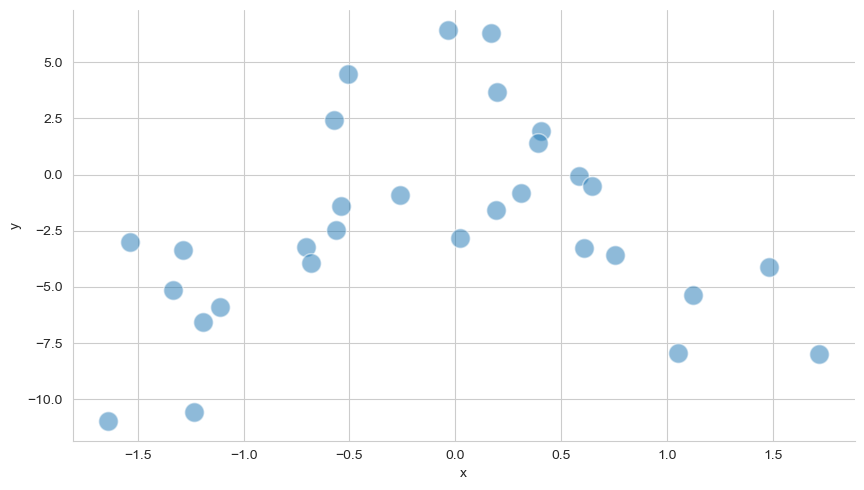

```python
sns.set_style('whitegrid')

sns.relplot(data = demo_df, x='x', y='y', s=200, alpha=0.5, aspect=1.75)

plt.show()
```

## Model fitting

Although we tried out 9 polynomials previously, let's just focus on 3 of the models in this notebook. We will use the quadratic, 5th degree polynomial, and the 8th degree polynomial.

```python
my_formulas = ['y ~ x + np.power(x,2)',
               'y ~ x + np.power(x,2) + np.power(x,3) + np.power(x,4) + np.power(x,5)',
               'y ~ x + np.power(x,2) + np.power(x,3) + np.power(x,4) + np.power(x,5) + np.power(x,6) + np.power(x,7) + np.power(x,8)'
              ]
```

The models are fit with `statsmodels` below.

```python
lm_fit_list = []

for a_formula in my_formulas:
    lm_fit_list.append( smf.ols(formula = a_formula, data = demo_df).fit() )
```

And we know that the most complex model (in this example the 8th degree polynomial) has the best performance on the training set.

```python
[ mod.rsquared for mod in lm_fit_list ]
```

```
[0.5221340909320277, 0.5956298413496184, 0.7083841270273737]
```

## K-fold cross-validation

We already visualized the coefficients and training set performance with these models. So we will instead focus on their behavior under various K-fold cross-validation procedures.

### 5-fold

We will start out with the same 5-fold cross-validation strategy.

```python
kf05 = KFold(n_splits=5, shuffle=True, random_state=101)
```

Let's extract each fold's respective training and hold-out test set. We do not need to do this when we use the `sklearn` functions such as `cross_val_score()`, but we will work with the fold's data splits manually in this notebook. Doing so will help us visualize how cross-validation "manages" the data across the folds.

```python
def extract_folds(df, cv):
    train_list = []
    test_list = []

    for train_id, test_id in cv.split(df.to_numpy()):
        train_list.append(df.iloc[train_id, :])
        test_list.append(df.iloc[test_id, :])

    return (train_list, test_list)
```

```python
train_05_list, test_05_list = extract_folds(demo_df.loc[:, ['x', 'y']].copy(), kf05)
```

Let's check the number of rows for each of the data sets per fold.

```python
print([ fold.shape[0] for fold in train_05_list ])

print([ fold.shape[0] for fold in test_05_list ])
```

```
[24, 24, 24, 24, 24]
[6, 6, 6, 6, 6]
```

Let's now visualize the train/test splits per fold, just like we did in lecture. The marker color in the figure below shows which points are used for training and which points are used for testing. The grey markers are the fold's training set, while the red points are the fold's test set.

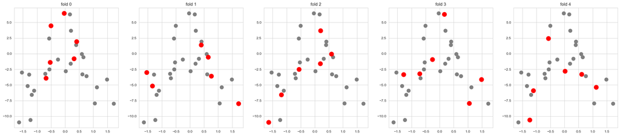

```python
fig, axs = plt.subplots(1, len(train_05_list), figsize=(30,6))

axs = axs.ravel()

for ii, ax in enumerate(axs):
    ax.scatter( train_05_list[ii].x, train_05_list[ii].y, s=100, color='grey')
    ax.scatter( test_05_list[ii].x, test_05_list[ii].y, s=150, color='red')
    ax.set_title('fold '+str(ii))

plt.show()
```

Let's now define a function which allows us to train and assess a model using cross-validation. We will store the squared error for each test point, rather than just storing the Mean Squared Error (MSE) associated with the fold's test set.

```python
def train_and_assess_in_fold(mod_id, a_formula, train_list, test_list):
    # loop over each fold
    for ii in range(len(train_list)):
        # train model in fold
        fold_mod = smf.ols(formula = a_formula, data = train_list[ii]).fit()
        # predict fold test set
        test_list[ii]['pred'] = fold_mod.predict( test_list[ii] )
        # calculate errors
        test_list[ii]['error'] = test_list[ii].y - test_list[ii].pred
        # calculate squared error
        test_list[ii]['squared_error'] = test_list[ii].error ** 2
        # add in the fold ID
        test_list[ii]['fold'] = 'fold ' + str(ii)

    # concat all fold's together
    test_res_df = pd.concat( test_list )

    # add in the model id
    test_res_df['mod_id'] = mod_id

    return test_res_df
```

Let's now train and assess each of our models with our 5-fold cross-validation strategy.

```python
result_k05_list = []

for an_id, a_formula in enumerate(my_formulas):
    result_k05_list.append( train_and_assess_in_fold(an_id, a_formula, train_05_list, test_05_list) )
```

```python
result_k05_df = pd.concat( result_k05_list )
```

The `.info()` for our compiled result DataFrame is shown below.

```python
result_k05_df.info()
```

```
<class 'pandas.core.frame.DataFrame'>
Index: 90 entries, 2 to 29
Data columns (total 7 columns):
 #   Column         Non-Null Count  Dtype
---  ------         --------------  -----
 0   x              90 non-null     float64
 1   y              90 non-null     float64
 2   pred           90 non-null     float64
 3   error          90 non-null     float64
 4   squared_error  90 non-null     float64
 5   fold           90 non-null     object
 6   mod_id         90 non-null     int64
dtypes: float64(5), int64(1), object(1)
memory usage: 5.6+ KB
```

And we can see that there are 5 unique values for the `fold` and `3` values for `mod_id`.

```python
result_k05_df.nunique()
```

```
x                30
y                30
pred             90
error            90
squared_error    90
fold              5
mod_id            3
dtype: int64
```

The unique `mod_id` values are just integers.

```python
result_k05_df.mod_id.value_counts()
```

```
mod_id
0    30
1    30
2    30
Name: count, dtype: int64
```

So let's add in more descriptive names.

```python
model_names_df = pd.DataFrame({'mod_id': [d for d in range(len(my_formulas))],
                              'model_name': [ str(d) + ' degree' for d in [2, 5, 8]]})
```

```python
result_k05_df = result_k05_df.merge( model_names_df, on='mod_id', how='left')
```

Let's now visualize the squared errors in each fold per model using a strip plot which shows one marker per test point per fold. As we can see below, the y-axis scale is dominated by the 8th degree polynomial.

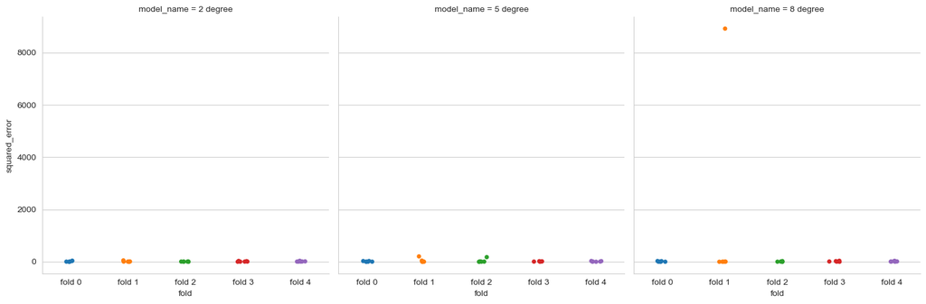

```python
sns.catplot(data = result_k05_df, x='fold', y='squared_error', hue='fold', col='model_name', kind='strip')

plt.show()
```

Let's zoom in by setting the y-axis limits.

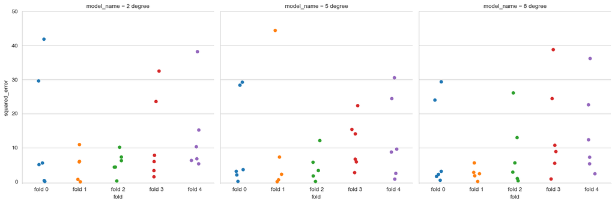

```python
sns.catplot(data = result_k05_df, x='fold', y='squared_error', hue='fold', s=35, col='model_name', kind='strip')

plt.ylim(-0.5, 50)

plt.show()
```

There are 6 points per fold per model because as we saw there are 6 points in each fold's test set. We cannot see all 6 points for all folds and models, so let's group and aggregate to confirm that there are in fact 6 points per fold per model.

```python
result_k05_df.groupby(['model_name', 'fold']).size().reset_index(name='num_rows')
```

|  | model_name | fold | num_rows |
| --- | --- | --- | --- |
| 0 | 2 degree | fold 0 | 6 |
| 1 | 2 degree | fold 1 | 6 |
| 2 | 2 degree | fold 2 | 6 |
| 3 | 2 degree | fold 3 | 6 |
| 4 | 2 degree | fold 4 | 6 |
| 5 | 5 degree | fold 0 | 6 |
| 6 | 5 degree | fold 1 | 6 |
| 7 | 5 degree | fold 2 | 6 |
| 8 | 5 degree | fold 3 | 6 |
| 9 | 5 degree | fold 4 | 6 |
| 10 | 8 degree | fold 0 | 6 |
| 11 | 8 degree | fold 1 | 6 |
| 12 | 8 degree | fold 2 | 6 |
| 13 | 8 degree | fold 3 | 6 |
| 14 | 8 degree | fold 4 | 6 |

Now when we perform cross-validation, for example with `cross_val_score()`, we will **not** get a result for each test point. Instead, the summary metric is returned for each fold. Since we are interested in the MSE, the average squared error is calculated per fold per model. Let's see what that fold MSE looks like per model. The black markers in the figure below are the fold average squared error (the MSE). The black line connects the fold MSE to show the fold-to-fold variation in the MSE.

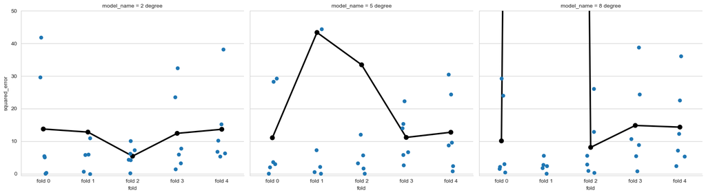

```python
g = sns.FacetGrid(data = result_k05_df, col='model_name', height=5, aspect=1.2)

g.map_dataframe(sns.stripplot, x='fold', y='squared_error', s=7)

g.map_dataframe(sns.pointplot, x='fold', y='squared_error', errorbar=None, color='black')

g.set(ylim=(-0.5, 50))

plt.show()
```

So how do we use K-fold cross-validation to compare model performance? We calculate the AVERAGE of the MSE values across the folds. Let's first show calculating the fold MSE per model.

```python
result_k05_df.groupby(['model_name', 'fold']).\
aggregate(fold_mse = ('squared_error', 'mean')).\
reset_index()
```

|  | model_name | fold | fold_mse |
| --- | --- | --- | --- |
| 0 | 2 degree | fold 0 | 13.735021 |
| 1 | 2 degree | fold 1 | 12.797083 |
| 2 | 2 degree | fold 2 | 5.405200 |
| 3 | 2 degree | fold 3 | 12.406555 |
| 4 | 2 degree | fold 4 | 13.651942 |
| 5 | 5 degree | fold 0 | 11.050007 |
| 6 | 5 degree | fold 1 | 43.374718 |
| 7 | 5 degree | fold 2 | 33.446416 |
| 8 | 5 degree | fold 3 | 11.154044 |
| 9 | 5 degree | fold 4 | 12.739858 |
| 10 | 8 degree | fold 0 | 10.089950 |
| 11 | 8 degree | fold 1 | 1488.155693 |
| 12 | 8 degree | fold 2 | 8.104694 |
| 13 | 8 degree | fold 3 | 14.830055 |
| 14 | 8 degree | fold 4 | 14.317456 |

And finally let's calculate the average MSE per model.

```python
result_k05_df.groupby(['model_name', 'fold']).\
aggregate(fold_mse = ('squared_error', 'mean')).\
reset_index().\
groupby(['model_name']).\
aggregate(cv_mse = ('fold_mse', 'mean'),
         cv_mse_se = ('fold_mse', 'sem')).\
reset_index()
```

|  | model_name | cv_mse | cv_mse_se |
| --- | --- | --- | --- |
| 0 | 2 degree | 11.599160 | 1.568883 |
| 1 | 5 degree | 22.353009 | 6.747456 |
| 2 | 8 degree | 307.099570 | 295.266748 |

These are the same numbers presented in the previous example. This is to highlight that the Cross-Validation or Resampled average performance metric is the average **of** averages! The performance within each fold is summarized, such as by calculating the average error metric within the fold. Then the fold average values are further averaged in order to determine the **expected** performance for the model!

### 10-fold

Let's now see what it looks like if we increase the number of folds. We will try 10-fold cross-validation.

```python
kf10 = KFold(n_splits=10, shuffle=True, random_state=102)
```

Let's extract the fold training and test sets.

```python
train_10_list, test_10_list = extract_folds(demo_df.loc[:, ['x', 'y']].copy(), kf10)
```

By increasing the number of folds, we are reducing the number of test points per fold. For this specific example that means we have just 3 data points used to test the model per fold. **In general with 10-fold cross-validation, 10% of the data points are used for testing within each fold.**

```python
print([ fold.shape[0] for fold in train_10_list ])

print([ fold.shape[0] for fold in test_10_list ])
```

```
[27, 27, 27, 27, 27, 27, 27, 27, 27, 27]
[3, 3, 3, 3, 3, 3, 3, 3, 3, 3]
```

Let's now visualize the training vs test sets within each fold, as we did previously. Again the red markers correpsond to the test points per fold and the grey markers are the training points within each fold.

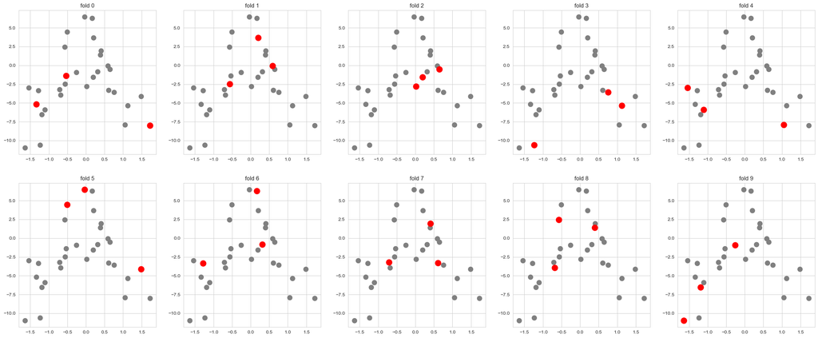

```python
fig, axs = plt.subplots(2, int(np.floor( len(train_10_list) / 2)), figsize=(30,12))

axs = axs.ravel()

for ii, ax in enumerate(axs):
    ax.scatter( train_10_list[ii].x, train_10_list[ii].y, s=100, color='grey')
    ax.scatter( test_10_list[ii].x, test_10_list[ii].y, s=150, color='red')
    ax.set_title('fold '+str(ii))

plt.show()
```

Let's now train each model with the 10-fold cross-validation strategy. This means each model will be trained 10 times, using the 27 training points per fold. Each model will be tested or assessed 10 times using the 3 test points within each fold. Something that is important to note is that a model is tested on that fold's corresponding test points. A model is never trained with one fold's training set and tested with a different fold's test points. For example, a model is trained with fold 1's training points and tested with fold 1's test points. A model is trained with fold 2's training points and tested with fold 2's test points. A model is **never** trained with fold 2's training points and tested with fold 1's test points. **Why do you think that is the case?**

```python
result_k10_list = []

for an_id, a_formula in enumerate(my_formulas):
    result_k10_list.append( train_and_assess_in_fold(an_id, a_formula, train_10_list, test_10_list) )
```

```python
result_k10_df = pd.concat( result_k10_list )
```

```python
result_k10_df = result_k10_df.merge( model_names_df, on='mod_id', how='left')
```

Let's check the number of unique values for each column in `result_k10_df`. As shown below, there are 10 unique values for `fold` because we are using 10-fold cross-validation.

```python
result_k10_df.nunique()
```

```
x                30
y                30
pred             90
error            90
squared_error    90
fold             10
mod_id            3
model_name        3
dtype: int64
```

Let's now visualize the squared errors per fold, per model using a strip plot.

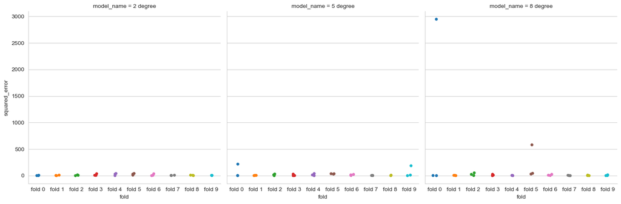

```python
sns.catplot(data = result_k10_df, x='fold', y='squared_error', hue='fold', col='model_name')

plt.show()
```

Again, we see that the y-axis scale is dominated by the 8th-degree model. So let's zoom in.

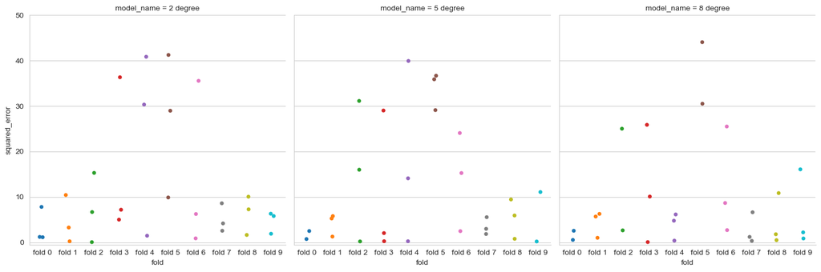

```python
sns.catplot(data = result_k10_df, x='fold', y='squared_error', hue='fold', s=25, col='model_name')

plt.ylim(-0.5, 50)

plt.show()
```

We should see 3 data points for each fold per model (unless the squared error is larger than the zoomed in scale). Again the errors are calculated by predicting the fold test points using models fit with each fold's training set. The errors are then squared, and we are visualizing the squared error for each test point in each fold, per model.

The fold MSE is calculated by averaging the squared error within each fold per model. The figure below displays the fold MSE as a black dot. If you look closely you should see that the black dot is the average of the squared errors within each fold.

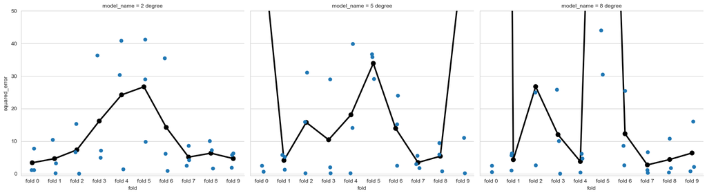

```python
g = sns.FacetGrid(data = result_k10_df, col='model_name', height=5, aspect=1.2)

g.map_dataframe(sns.stripplot, x='fold', y='squared_error', s=7)

g.map_dataframe(sns.pointplot, x='fold', y='squared_error', errorbar=None, color='black')

g.set(ylim=(-0.5, 50))

plt.show()
```

10-fold cross-validation has fewer test points per fold than 5-fold cross-validation. Therefore 10-fold has greater fold-to-fold variation in the MSE compared with 5-fold. Let's confirm this is the case by direclty comparing the fold MSE values between the 5-fold and 10-fold results. Obviously, the test points are different and so what we will really care about is the variation across the folds not the value of the MSE within a particular fold.

```python
result_k05_df_copy = result_k05_df.copy()
result_k05_df_copy['K'] = 5

result_k10_df_copy = result_k10_df.copy()
result_k10_df_copy['K'] = 10

compare_cvs = pd.concat( [result_k05_df_copy, result_k10_df_copy], ignore_index=True )
```

The hue or color is used to denote the number of folds. Again, we are not directly comparing the MSE in fold 1 when we use 5-fold vs 10-fold. We are interested in the fold-to-fold variation. The greater fold-to-fold variation is easier to see with the quadratic model than the other two models.

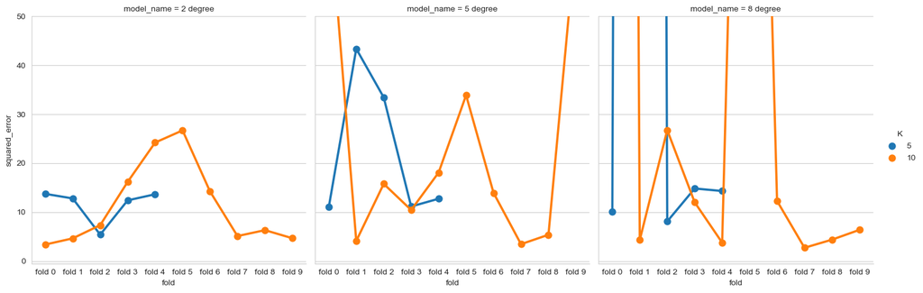

```python
sns.catplot( data = compare_cvs, x='fold', y='squared_error', hue='K', col='model_name', kind='point', errorbar=None)

plt.ylim(-0.5, 50)

plt.show()
```

So why would we want to consider more folds? The overall model performance is calculated by **averaging across the folds**. The **standard error** on the average consists of two components: the standard deviation of the MSE across the folds and the square root of the number of folds! This is the same standard error we spent so much time with in CMPINF 2100! Therefore, even if we have greater variation in the performance across the folds, averaging over more folds may give a more precise estimate of the average behavior.

For this specific example, the behavior across the 5-folds is more consistent than the benefit of the great number of folds. That is why the standard error error on the average (`mse_se` in the result below) is lower for the 5-fold case for the quadratic model. However, a different application may yield different results. For example, the 8th degree polynomial has a lower standard error on the average hold out set performance when 10 folds are used compared to 5 folds.

```python
compare_cvs.groupby(['model_name', 'K', 'fold']).\
aggregate(fold_mse = ('squared_error', 'mean')).\
reset_index().\
groupby(['model_name', 'K']).\
aggregate(avg_mse = ('fold_mse', 'mean'),
          sd_mse = ('fold_mse', 'std'),
         mse_se = ('fold_mse', 'sem')).\
reset_index()
```

|  | model_name | K | avg_mse | sd_mse | mse_se |
| --- | --- | --- | --- | --- | --- |
| 0 | 2 degree | 5 | 11.599160 | 3.508129 | 1.568883 |
| 1 | 2 degree | 10 | 11.277649 | 8.602703 | 2.720414 |
| 2 | 5 degree | 5 | 22.353009 | 15.087771 | 6.747456 |
| 3 | 5 degree | 10 | 24.469182 | 25.544550 | 8.077896 |
| 4 | 8 degree | 5 | 307.099570 | 660.236521 | 295.266748 |
| 5 | 8 degree | 10 | 127.439832 | 307.938760 | 97.378786 |

### Leave-One-Out (LOO)

We can keep increasing the number of folds, with the most rigorous approach being Leave-One-Out cross-validation (LOOCV). As the name states, only a single data point is left out per fold. Thus, if we have $N$ data points each fold has $N-1$ training points and $1$ test point. In our current example that means we have 30 folds and 29 training points per fold. LOOCV is not all that commmon to use. For example, if we have 100,000 data points we would need 100,000 folds. Thus, we will train a model 100,000 times! LOOCV allows us to get a sense of which specific data points are the most difficult or problematic. Because we are literally testing against each data point.

Let's go through the steps of implementing LOOCV for our simple example. LOOCV does not require us to randomly choose data points, because we testing against each data point, but just for consistency we will use `KFold()` to generate the folds.

```python
kfloo = KFold(n_splits=demo_df.shape[0], shuffle=True, random_state=103)

train_loo_list, test_loo_list = extract_folds(demo_df.loc[:, ['x', 'y']].copy(), kfloo)
```

As we can see below, each fold has 29 training points and 1 test point.

```python
print([ fold.shape[0] for fold in train_loo_list ])

print([ fold.shape[0] for fold in test_loo_list ])
```

```
[29, 29, 29, 29, 29, 29, 29, 29, 29, 29, 29, 29, 29, 29, 29, 29, 29, 29, 29, 29, 29, 29, 29, 29, 29, 29, 29, 29, 29, 29]
[1, 1, 1, 1, 1, 1, 1, 1, 1, 1, 1, 1, 1, 1, 1, 1, 1, 1, 1, 1, 1, 1, 1, 1, 1, 1, 1, 1, 1, 1]
```

Visualizing the folds again makes it clear there is just a single test point per fold.

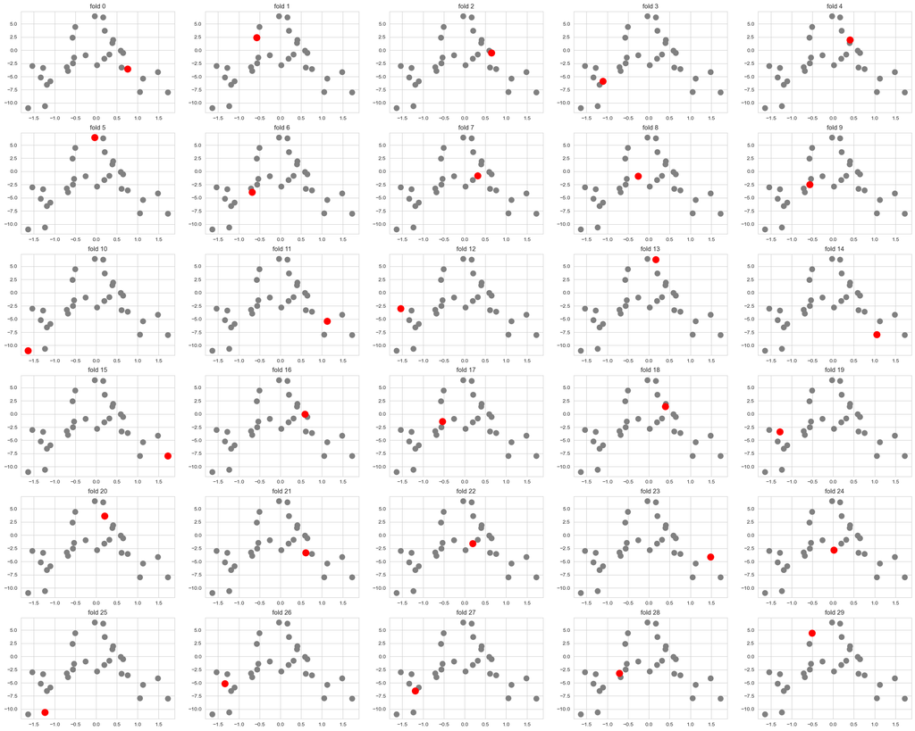

```python
fig, axs = plt.subplots(6, int(np.floor( len(train_loo_list) / 6)), figsize=(30,24))

axs = axs.ravel()

for ii, ax in enumerate(axs):
    ax.scatter( train_loo_list[ii].x, train_loo_list[ii].y, s=100, color='grey')
    ax.scatter( test_loo_list[ii].x, test_loo_list[ii].y, s=150, color='red')
    ax.set_title('fold '+str(ii))

plt.show()
```

Let's train and test the models in each fold.

```python
result_loo_list = []

for an_id, a_formula in enumerate(my_formulas):
    result_loo_list.append( train_and_assess_in_fold(an_id, a_formula, train_loo_list, test_loo_list) )
```

```python
result_loo_df = pd.concat( result_loo_list )
```

```python
result_loo_df = result_loo_df.merge( model_names_df, on='mod_id', how='left')
```

Plotting the squared error reveals there is just a single data point per fold per model!

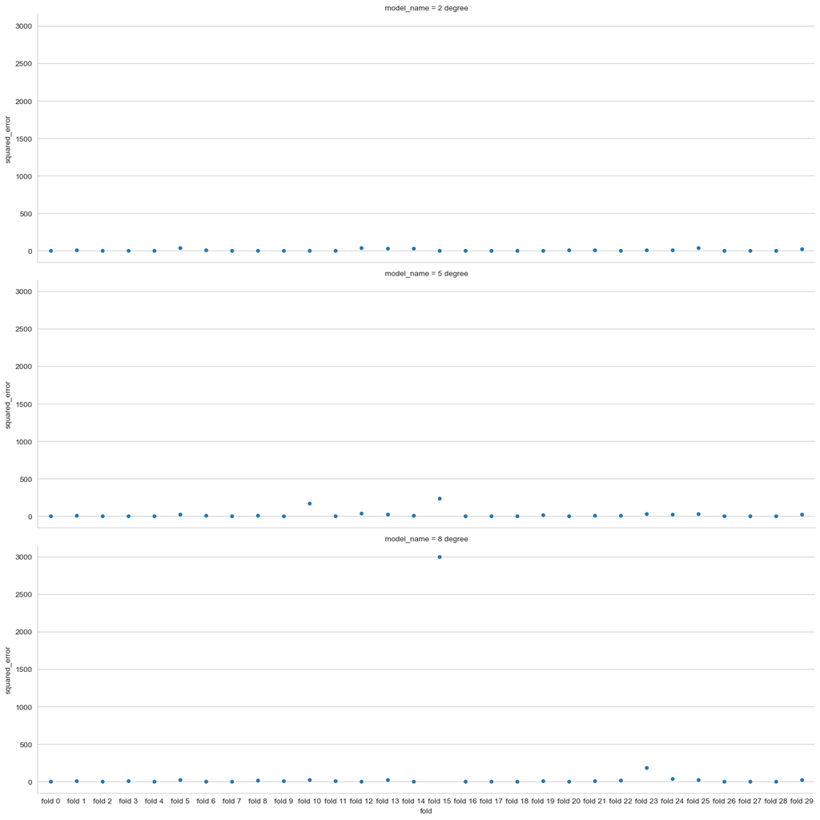

```python
sns.catplot(data = result_loo_df, x='fold', y='squared_error', row='model_name', aspect=3)

plt.show()
```

Since there is just a single test point per fold, the fold MSE is just equal to the squared error of that single data point!

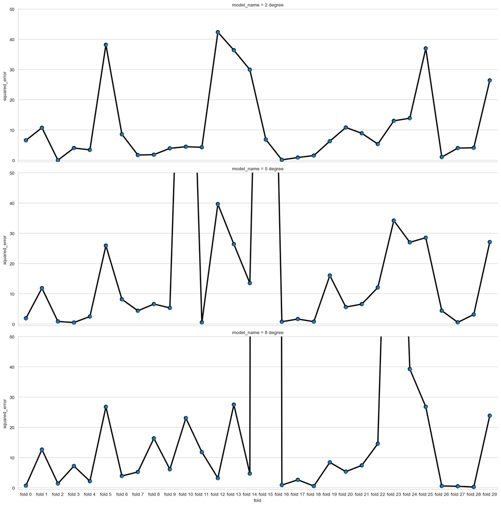

```python
g = sns.FacetGrid(data = result_loo_df, row='model_name', height=5, aspect=3)

g.map_dataframe(sns.stripplot, x='fold', y='squared_error', s=7)

g.map_dataframe(sns.pointplot, x='fold', y='squared_error', errorbar=None, color='black')

g.set(ylim=(-0.5, 50))

plt.show()
```

Let's now compare the LOOCV summary performance metrics with those from 5-fold and 10-fold.

```python
result_loo_df_copy = result_loo_df.copy()
result_loo_df_copy['K'] = demo_df.shape[0]

compare_cvs = pd.concat( [compare_cvs, result_loo_df_copy] )
```

```python
compare_cvs.groupby(['model_name', 'K', 'fold']).\
aggregate(fold_mse = ('squared_error', 'mean')).\
reset_index().\
groupby(['model_name', 'K']).\
aggregate(avg_mse = ('fold_mse', 'mean'),
          sd_mse = ('fold_mse', 'std'),
         mse_se = ('fold_mse', 'sem')).\
reset_index()
```

|  | model_name | K | avg_mse | sd_mse | mse_se |
| --- | --- | --- | --- | --- | --- |
| 0 | 2 degree | 5 | 11.599160 | 3.508129 | 1.568883 |
| 1 | 2 degree | 10 | 11.277649 | 8.602703 | 2.720414 |
| 2 | 2 degree | 30 | 11.216720 | 12.841590 | 2.344543 |
| 3 | 5 degree | 5 | 22.353009 | 15.087771 | 6.747456 |
| 4 | 5 degree | 10 | 24.469182 | 25.544550 | 8.077896 |
| 5 | 5 degree | 30 | 24.094829 | 50.872071 | 9.287927 |
| 6 | 8 degree | 5 | 307.099570 | 660.236521 | 295.266748 |
| 7 | 8 degree | 10 | 127.439832 | 307.938760 | 97.378786 |
| 8 | 8 degree | 30 | 115.711878 | 545.860192 | 99.659980 |

As we can see above, even though the quadratic model has a higher standard deviation of the fold MSE values with LOO (K=30) compared to 10-fold, the standard error on the mean is slightly lower with LOO than 10-fold. The lowest standard error for the quadratic model is still the 5-fold case for this specific example. Note that the different average MSE values are well within the $\pm1$ standard error interval around the case with the lowest standard error for the quadratic model.

## Repeated K-fold

We saw that with our specific example, 5-fold cross-validation resulted in the lowest standard error on the average MSE. In 5-fold 20% of the data is used for testing within each fold, providing more averaging within a single fold than 10-fold. For our specific application, that averaging produced quite consistent fold test-set performances. This may not always be the case though. Sometimes small numbers of folds can "wash out" the behavior of particularly challenging data points. Or, perhaps the folds are just the "lucky" combination of randomly selected test points that allows for overly complex models which are actually overfit to "sneak through".

For those reasons I particularlly like to use **Repeated K-fold cross-validation**. I will often use 5-fold with 5-repeats. Therefore providing 20% of the data per fold, but randomly creating the 5-folds 5 times. The downside of repeated cross-validation is that we are training the models more times. With 5-folds repeated 5 times, each model is trained 25 times! Thus, if a model is time consuming to train, I might use 5-fold with 3-repeats instead.

The `sklearn` method `RepeatedKFold()` creates the folds for us, given a desired number of repeats. Let's see what 5-fold with 5-repeats looks like.

```python
from sklearn.model_selection import RepeatedKFold
```

The `RepeatedKFold()` syntax is similar to `KFold()`, except we need to specify the number of repeats.

```python
k5r5 = RepeatedKFold(n_splits=5, n_repeats=5, random_state=101)
```

Let's next extract all folds so we can visualize the training/test splits within each repeated fold.

```python
train_k5r5_list, test_k5r5_list = extract_folds(demo_df.loc[:, ['x', 'y']].copy(), k5r5)
```

Each fold contains 20% of the data for testing, as shown below.

```python
print([ fold.shape[0] for fold in train_k5r5_list ])

print([ fold.shape[0] for fold in test_k5r5_list ])
```

```
[24, 24, 24, 24, 24, 24, 24, 24, 24, 24, 24, 24, 24, 24, 24, 24, 24, 24, 24, 24, 24, 24, 24, 24, 24]
[6, 6, 6, 6, 6, 6, 6, 6, 6, 6, 6, 6, 6, 6, 6, 6, 6, 6, 6, 6, 6, 6, 6, 6, 6]
```

Visualizing the training/test splits shows each repeat contains a different set of test point. Because we are randomly selecting the points each time!

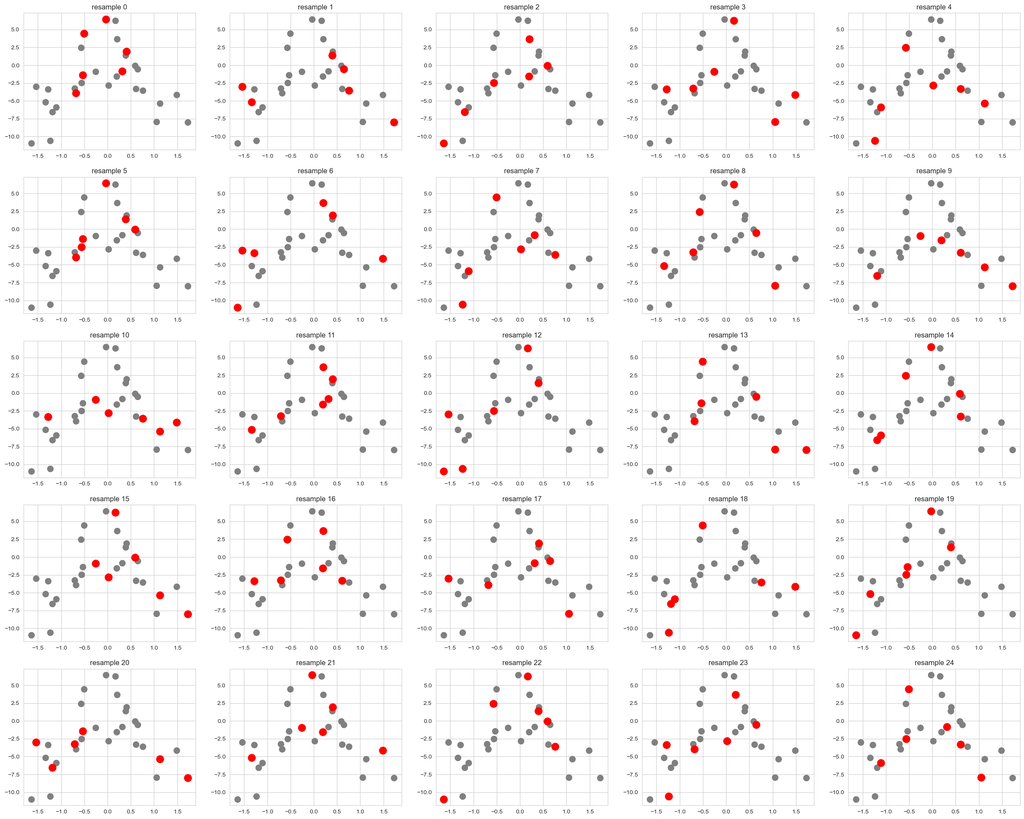

```python
fig, axs = plt.subplots(5, 5, figsize=(30,24))

axs = axs.ravel()

for ii, ax in enumerate(axs):
    ax.scatter( train_k5r5_list[ii].x, train_k5r5_list[ii].y, s=100, color='grey')
    ax.scatter( test_k5r5_list[ii].x, test_k5r5_list[ii].y, s=150, color='red')
    ax.set_title('resample '+str(ii))

plt.show()
```

We could go through and manually perform the cross-validation as we did before, but let's use the built-in function `cross_val_score()` along with `sklearn`'s `LinearRegression()` method. This way we can see how to apply repeated cross-validation to models using the existing tools.

```python
from sklearn.linear_model import LinearRegression
from sklearn.model_selection import cross_val_score
```

We will use the function created in the material presented in lecture, which allows passing in a formula to fit the model. To support that approach we also need `dmatrices()` from `patsy`.

```python
from patsy import dmatrices
```

The function we need is defined below.

```python
def score_models_with_cv(a_formula, mod_id, cv, mod, df, score_to_use):
    # create the features
    y, X = dmatrices(a_formula, df)

    # execute the cross-validation
    score_value = cross_val_score(mod, X, y.ravel(), cv=cv, scoring=score_to_use)

    # package everything together
    res = pd.DataFrame({'score': score_value})

    res['mod_id'] = mod_id
    res['fold_id'] = list(range(len(score_value)))

    return res
```

Let's now fit each of the 3 polynomial models we have worked with in this notebook, using 5-fold cross-validation with 5-repeats to assess their performance. We will "score" the models by calculating the "negative mean squared error".

```python
my_mse_cv_results = []

for ii, a_formula in enumerate(my_formulas):
    my_mse_cv_results.append(score_models_with_cv(a_formula, ii, k5r5, LinearRegression(fit_intercept=True), demo_df,
                                                  'neg_mean_squared_error'))
```

Let's multiply the negative mean squared error by negative one so we can work with the MSE directly.

```python
my_mse_cv_results_df = pd.concat( my_mse_cv_results )

my_mse_cv_results_df['mse'] = - my_mse_cv_results_df['score']
```

```python
my_mse_cv_results_df = my_mse_cv_results_df.merge( model_names_df, on='mod_id', how='left')
```

And now let's compare the three models.

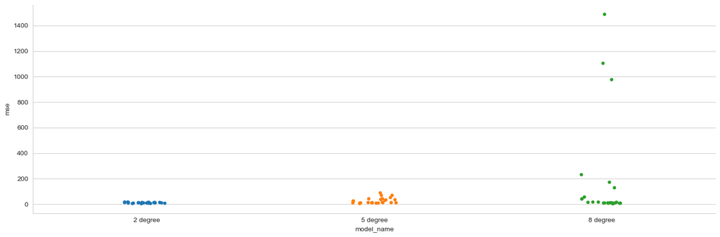

```python
sns.catplot(data = my_mse_cv_results_df, x='model_name', hue='model_name', y='mse', aspect=3)

plt.show()
```

The cross-validation performance is then the average of the 25 repeated folds.

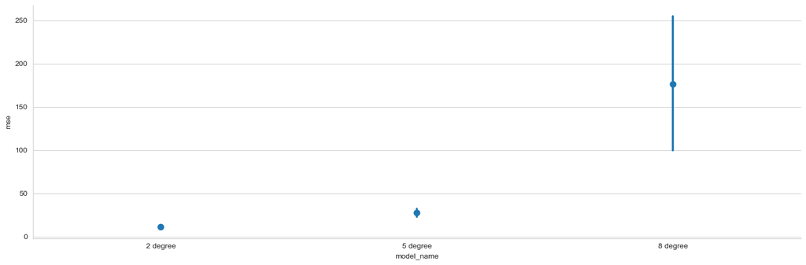

```python
sns.catplot(data = my_mse_cv_results_df, x='model_name', y='mse', kind='point', errorbar=('ci', 68), join=False, aspect=3)

plt.show()
```

The $\pm1$ standard error interval on the average is displayed above. We can look at the standard error directly by calculating it with groupby and aggregate. With 25 effective observations of the MSE the standard error on the average performance is quite low, in this example.

```python
my_mse_cv_results_df.groupby(['model_name']).\
aggregate(avg_mse = ('mse', 'mean'),
         sd_mse = ('mse', 'std'),
         mse_se = ('mse', 'sem')).\
reset_index()
```

|  | model_name | avg_mse | sd_mse | mse_se |
| --- | --- | --- | --- | --- |
| 0 | 2 degree | 11.033976 | 3.514658 | 0.702932 |
| 1 | 5 degree | 27.424601 | 22.723634 | 4.544727 |
| 2 | 8 degree | 176.082783 | 393.719640 | 78.743928 |

## Summary

This report demonstrated how cross-validation is used to identify the best model in greater detail. It also showed the differences between 5-fold, 10-fold, LOOCV, and Repeated Cross-Validation.